# The hypergraph Laplacian family

hypergraph_laplacian(), hypergraph_cluster(), hypergraph_transduction()

honets

2026-08-26

## The analytic question

Spectral methods — clustering, label propagation, diffusion — all run off a Laplacian. Defining one for a hypergraph is not automatic, because a hyperedge connects many nodes at once and there is no single obvious way to distribute that connection.

This family implements two answers:

- **`type = "zhou"`** (default) — the weighted normalised Laplacian of Zhou, Huang & Schölkopf (2006). Each hyperedge spreads its weight evenly over its members.
- **`type = "random_walk"`** — the edge-dependent vertex weight walk of Hayashi et al. (2020). A step picks a hyperedge in proportion to its weight, then a node within it in proportion to that node’s weight *in that hyperedge*. When those within-edge weights vary, this carries information the Zhou construction averages away.

```r
library(honets)
hg <- window_hypergraph(human_long, action = "code", actor = "session_id",
                        time = "timestamp",
                        window = 3L, min_size = 2L, min_weight = 50L)
hg
```

```
Hypergraph: 9 nodes, 56 hyperedges
Size distribution:
  size_2   : 22
  size_3   : 34
Source: windowed sequences, window = 3, step = 1 (9942 windows from 429 sequences)
```

## The Laplacian itself

```r
L <- hypergraph_laplacian(hg)
dim(L)
```

```
[1] 9 9
```

```r
round(L[1:4, 1:4], 3)
```

```
          Command Correct Frustrate Inquire
Command     0.598  -0.079    -0.057  -0.104
Correct    -0.079   0.607    -0.082  -0.064
Frustrate  -0.057  -0.082     0.595  -0.049
Inquire    -0.104  -0.064    -0.049   0.603
```

It is a symmetric 9×9 matrix with the properties a Laplacian should have:

```r
ev <- sort(eigen(L, symmetric = TRUE, only.values = TRUE)$values)
round(head(ev, 4), 5)
```

```
[1] 0.00000 0.54832 0.58210 0.62009
```

The smallest eigenvalue is exactly 0 — the constant vector is always in the kernel. The **second** eigenvalue (0.548) is the spectral gap: how hard it is to cut this hypergraph in two. A large gap means well-connected, hard to split.

The stationary distribution of the associated walk comes along as an attribute, and the PageRank verb is the damped version of the same walk:

```r
round(sort(attr(L, "pi"), decreasing = TRUE), 4)
```

```
  Specify   Command   Request Frustrate   Correct Interrupt   Inquire    Refine
   0.2963    0.1812    0.1136    0.0853    0.0769    0.0739    0.0720    0.0696
   Verify
   0.0312
```

## Clustering

```r
cl <- hypergraph_cluster(hg, k = 3, seed = 1)
cl
```

```
Hypergraph spectral clustering (zhou Laplacian)
  Nodes: 9 | Hyperedges: 56 | k: 3
  Cluster sizes: Cluster 1 = 3, Cluster 2 = 3, Cluster 3 = 3
  Eigengap after k: 0.0380
```

```r
as.data.frame(cl)
```

```
       node   cluster         pi       dim1        dim2       dim3
1   Command Cluster 1 0.18122071 -0.7810245  0.60442681  0.1570635
2   Correct Cluster 2 0.07687997 -0.4952601 -0.70250989  0.5110746
3 Frustrate Cluster 2 0.08533727 -0.4845138 -0.77779303 -0.4003553
4   Inquire Cluster 1 0.07203994 -0.4238156  0.18180553  0.8873145
5 Interrupt Cluster 1 0.07387406 -0.5864673  0.70956123  0.3906135
6    Refine Cluster 2 0.06959446 -0.4312876 -0.88020425 -0.1980693
7   Request Cluster 3 0.11361321 -0.8025150  0.40116869 -0.4416258
8   Specify Cluster 3 0.29626044 -0.9914024  0.07437341 -0.1076566
9    Verify Cluster 3 0.03117995 -0.2363572  0.36788673 -0.8993301
```

Three clusters of three. Reading the membership: **Command, Inquire and Interrupt** group together; **Correct, Frustrate and Refine** form a second; **Request, Specify and Verify** a third. The second is recognisably a repair-and-revision cluster, the third a specify-and-check cluster.

`summary()` gives the sizes:

```r
summary(cl)
```

[output not shown]

### Check the eigengap before trusting `k`

The print method reports **Eigengap after k: 0.0380**. That is small. A well-separated `k`-cluster structure produces a large gap after the `k`-th eigenvalue; a small one means the choice of `k` is not strongly supported by the spectrum.

```r
do.call(rbind, lapply(2:5, function(k) {
  c_k <- hypergraph_cluster(hg, k = k, seed = 1)
  data.frame(k = k, sizes = paste(table(as.data.frame(c_k)$cluster),
                                  collapse = "/"))
}))
```

```
  k     sizes
1 2       6/3
2 3     3/3/3
3 4   2/3/3/1
4 5 3/2/2/1/1
```

`k` is your assumption, not a discovery. Report the eigengap alongside it, or show that the conclusion survives several values.

### Seeding

`hypergraph_cluster()` runs k-means on the spectral embedding, which is stochastic. Pass `seed`:

```r
identical(hypergraph_cluster(hg, k = 3, seed = 1),
          hypergraph_cluster(hg, k = 3, seed = 1))
```

```
[1] TRUE
```

`nstart` (default 25) controls how many k-means restarts are used; raise it if clusters move between seeds.

## Seeing the clustering

`plot()` gives two diagnostic panels: the Laplacian spectrum with the chosen `k` marked, and the spectral embedding the k-means step actually clustered. The eigengap after `k` is the evidence for (or against) the choice — read the scree panel before believing the assignment.

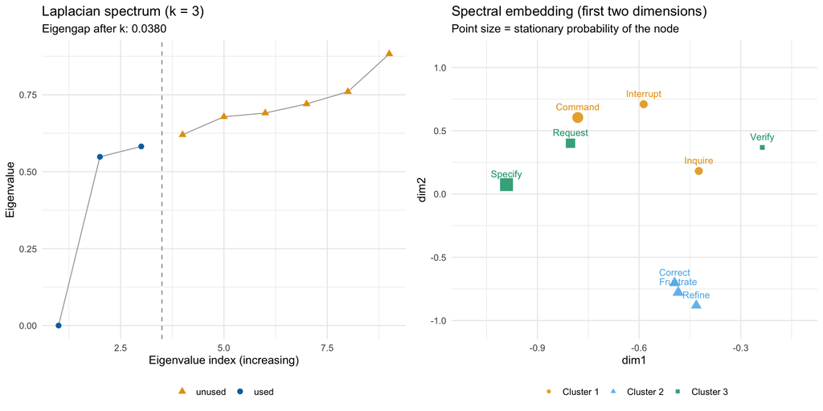

```r
plot(cl)
```

## Transductive label spreading

Label a few nodes, and let the hypergraph structure propagate labels to the rest.

```r
labs <- stats::setNames(c("directive", "evaluative"), c("Command", "Verify"))
tr <- hypergraph_transduction(hg, labels = labs, xi = 0.5)
tr
```

```
Hypergraph transductive label spreading (zhou Laplacian, xi = 0.5)
  Nodes: 9 (2 labeled) | Classes: directive, evaluative
  Predicted: directive = 8, evaluative = 1
```

```r
as.data.frame(tr)
```

```
       node      label  predicted      score     margin
1   Command  directive  directive 0.65562144 0.61843974
2   Correct       <NA>  directive 0.04695511 0.03953534
3 Frustrate       <NA>  directive 0.04030305 0.01306130
4   Inquire       <NA>  directive 0.05563511 0.04829022
5 Interrupt       <NA>  directive 0.05033524 0.03404671
6    Refine       <NA>  directive 0.02593930 0.01867132
7   Request       <NA>  directive 0.06253070 0.03859017
8   Specify       <NA>  directive 0.10786388 0.06510090
9    Verify evaluative evaluative 0.62903274 0.59185104
```

`score` is the confidence in the predicted class; `margin` is the gap to the runner-up. Small margins mean the structure did not decide strongly.

### The default `xi` can override your own seed labels

`xi` trades off *smoothness over the hypergraph* against *fidelity to the seeds*. It defaults to 0.99, which weights smoothness heavily — heavily enough that a seed label can be overturned:

```r
do.call(rbind, lapply(c(0.1, 0.5, 0.9, 0.99), function(x) {
  d <- as.data.frame(hypergraph_transduction(hg, labels = labs, xi = x))
  data.frame(xi = x,
             Verify_seeded_as = "evaluative",
             Verify_predicted = d$predicted[d$node == "Verify"],
             n_evaluative = sum(d$predicted == "evaluative"))
}))
```

```
    xi Verify_seeded_as Verify_predicted n_evaluative
1 0.10       evaluative       evaluative            1
2 0.50       evaluative       evaluative            1
3 0.90       evaluative       evaluative            1
4 0.99       evaluative        directive            0
```

At `xi = 0.99` — **the default** — Verify is predicted `directive` despite being seeded `evaluative`, and the evaluative class disappears entirely. At `xi ≤ 0.9` the seed holds.

This is the documented behaviour of Zhou’s algorithm, not a bug: with one seed per class and a strongly-connected structure, 99% smoothing swamps the 1% fidelity term. But it means **you must check that your seeds survive**. Lower `xi`, or seed more nodes:

```r
labs2 <- stats::setNames(
  c("directive", "directive", "evaluative", "evaluative"),
  c("Command", "Specify", "Verify", "Correct"))
as.data.frame(hypergraph_transduction(hg, labels = labs2, xi = 0.9))
```

```
       node      label  predicted     score     margin
1   Command  directive  directive 0.4961007 0.32723276
2   Correct evaluative evaluative 0.2467516 0.01567389
3 Frustrate       <NA>  directive 0.2383229 0.11568980
4   Inquire       <NA>  directive 0.2278996 0.12670839
5 Interrupt       <NA>  directive 0.2353927 0.13602862
6    Refine       <NA>  directive 0.2173694 0.11675687
7   Request       <NA>  directive 0.2924019 0.16693809
8   Specify  directive  directive 0.5826452 0.36790591
9    Verify evaluative evaluative 0.2143014 0.06177187
```

## Seeing the spreading

The full node-by-class score matrix, with seed nodes outlined in black and each node’s winning class marked. Rows where the winning and runner-up scores are close are the assignments to distrust — that closeness is visible here and invisible in a table of predicted labels.

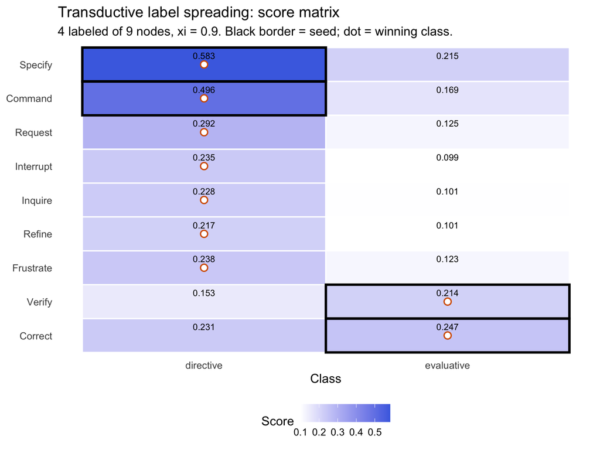

```r
plot(hypergraph_transduction(hg, labels = labs2, xi = 0.9))
```

## Both Laplacians

```r
do.call(rbind, lapply(c("zhou", "random_walk"), function(ty) {
  Lt <- hypergraph_laplacian(hg, type = ty)
  e <- sort(eigen(Lt, symmetric = TRUE, only.values = TRUE)$values)
  data.frame(type = ty, lambda_2 = round(e[2], 4),
             lambda_max = round(max(e), 4))
}))
```

```
         type lambda_2 lambda_max
1        zhou   0.5483     0.8828
2 random_walk   0.5574     0.8749
```

Use `random_walk` when the incidence carries genuinely edge-dependent vertex weights — as `window_hypergraph()` produces, where a cell is an occurrence count within a window. On a binary incidence the two constructions carry the same information, and Chitra & Raphael’s collapse theorem says the walk is then equivalent to one on a weighted clique expansion.

## Connectivity is required

```r
iso <- group_hypergraph(
  data.frame(member = c("A", "B", "C", "D"),
             grp    = c("g1", "g1", "g2", "g2"), stringsAsFactors = FALSE),
  member = "member", group = "grp")
hypergraph_laplacian(iso)
```

```
Error:
! The hypergraph is not connected; the random walk has no unique stationary distribution. Analyze components separately.
```

A disconnected hypergraph has a degenerate spectrum — the multiplicity of eigenvalue 0 equals the number of components — so these verbs refuse it with a classed `honets_hypergraph_disconnected` condition rather than returning something meaningless. Split the components and analyse them separately.

## What to do next

- **`hypergraph_centrality()`** — the damped version of this same random walk.
- **`hypergraph_measures()`** — descriptive structure before the spectral analysis.
- **`window_hypergraph()`** — where the edge-dependent weights come from.

## References

- Zhou, D., Huang, J., & Schölkopf, B. (2006). Learning with hypergraphs: clustering, classification, and embedding. *NeurIPS 19*, 1601-1608.
- Hayashi, K., Aksoy, S. G., Park, C. H., & Park, H. (2020). Hypergraph random walks, Laplacians, and clustering. *CIKM 2020*, 495-504.
- Chitra, U., & Raphael, B. J. (2019). Random walks on hypergraphs with edge-dependent vertex weights. *ICML 2019*, PMLR 97, 1172-1181.
- von Luxburg, U. (2007). A tutorial on spectral clustering. *Statistics and Computing*, 17(4), 395-416.